# Introduction

#### I would like to build a single-index model for stocks price changes to evaluate the stocks' risk. The financial concept "high risk high return" means that the investors will be compensated for bearing high risk by higher return. However, some risks are firm specific risk that can be eliminated through portfolio diversification. Investors will only be compensated for the risk they bear that can not be eliminated by diversification, which is the systematic risk(also called market risk).

#### Basically, the project is running a regression of the return of stocks against the market return(approximated by S&P500) to find the correlation coefficient of a certain stock's return and the market changes. The correlation coefficient represents the systematic risk of the stock. By generating graphs of regression, one can judge the market risk of a specific stock from the slopes.

```python
import matplotlib.pyplot as plt
import numpy as np
import pandas as pd
import sklearn
from sklearn import datasets, linear_model
from sklearn.linear_model import LinearRegression
from sklearn.metrics import mean_squared_error, r2_score
import scipy.ndimage as ndimage
import statsmodels.api as sm

Df={}
ColHead=[]
Df_Raw = pd.DataFrame()
ParamList={}
```

# Preparation

#### 1. Get the full list of data documents from "name.txt"

#### 2. Read each of the stock price files and build a dataframe for each of the stock that keeps only the information for column "Date" and "Adjusted Closing Price"

#### 3. Modify the column name of "Adjusted Closing Price" to the stock name for later use

```python
def readName(filename):
    StockList = []
    file = open(filename)
    for line in file:
        StockList.append(line.rstrip())
    file.close()
    return StockList

StockList= readName("name.txt")

for i in StockList:
    NewStock=i.split('.')[0]
    Df[NewStock]= pd.DataFrame()
    Df[NewStock] = pd.read_csv(i,parse_dates=[0])
    names = ['Date','Adj Close']
    ColHead.append(NewStock)
    Df[NewStock] = Df[NewStock][names]
    Df[NewStock].columns = ['Date', NewStock]
```

#### 3. Merge the data frames into data frame "Df_Raw" on column "Date"

#### 4. Check for missing value and print the missing frequency

#### No missing value is found, Yahoo Finance (the data source) already handled the missing data for us.

```python
Df_Raw = Df["MARKET"]
for i in ColHead[1:]:
    Df_Raw=pd.merge(Df_Raw,Df[i],on='Date')

Df_Raw.head()
```

|  | Date | MARKET | FB | GE | GOOGL | HSBC | JNJ | JPM | KO | M | MCD | MMM | PEP | RL | SBUX | T | TGT | UPS | VZ | WMT |
| --- | --- | --- | --- | --- | --- | --- | --- | --- | --- | --- | --- | --- | --- | --- | --- | --- | --- | --- | --- | --- |
| 0 | 2014-01-02 | 1831.979980 | 54.709999 | 23.886345 | 557.117126 | 42.160526 | 81.022713 | 52.220573 | 35.486115 | 45.562309 | 84.665535 | 124.301926 | 72.758484 | 162.380676 | 35.439445 | 27.665697 | 54.821186 | 91.280251 | 39.850769 | 70.530853 |
| 1 | 2014-01-03 | 1831.369995 | 54.560001 | 23.868975 | 553.053040 | 41.789677 | 81.752556 | 52.624275 | 35.311565 | 45.690315 | 84.779686 | 124.589874 | 72.882568 | 164.065903 | 35.338409 | 27.546963 | 55.090172 | 91.077057 | 39.379059 | 70.298462 |
| 2 | 2014-01-06 | 1826.770020 | 57.200001 | 23.677885 | 559.219238 | 41.998283 | 82.179779 | 52.929283 | 35.145737 | 45.357494 | 84.173759 | 123.851952 | 72.918007 | 161.741806 | 34.980206 | 27.673613 | 54.717064 | 89.893196 | 39.598640 | 69.905159 |
| 3 | 2014-01-07 | 1837.880005 | 57.919998 | 23.703943 | 570.000000 | 42.925400 | 83.924332 | 52.319256 | 35.250465 | 44.529713 | 84.639175 | 123.869934 | 73.981483 | 162.408508 | 35.457813 | 27.665697 | 54.586903 | 90.184753 | 40.094757 | 70.119690 |
| 4 | 2014-01-08 | 1837.489990 | 58.230000 | 23.634459 | 571.186157 | 42.948574 | 83.808609 | 52.812668 | 34.857735 | 44.239559 | 83.787338 | 122.952057 | 73.768776 | 159.556671 | 35.834385 | 27.465168 | 54.396011 | 90.114082 | 39.872776 | 69.565521 |

```python
missing_frequency=Df_Raw.isna().sum()/ len(Df_Raw)
print(missing_frequency)
```

```
Date      0.0
MARKET    0.0
FB        0.0
GE        0.0
GOOGL     0.0
HSBC      0.0
JNJ       0.0
JPM       0.0
KO        0.0
M         0.0
MCD       0.0
MMM       0.0
PEP       0.0
RL        0.0
SBUX      0.0
T         0.0
TGT       0.0
UPS       0.0
VZ        0.0
WMT       0.0
dtype: float64
```

# Compute the daily return rate for each cell

#### 2. Create a new dataframe Df_Return that stores the daily return rate

#### 3. The price information are found in Df_Raw data frame

```python
Df_Return=Df_Raw.copy()

for i in Df_Return.columns[1:]:
    for j in range(0,Df_Return.shape[0]-1):
        Df_Return.loc[j+1, i]= (Df_Raw.loc[j+1, i]-Df_Raw.loc[j, i])/Df_Raw.loc[j, i]

Df_Return = Df_Return.iloc[1:]
```

```python
# Check for completeness
Df_Return.tail()
```

|  | Date | MARKET | FB | GE | GOOGL | HSBC | JNJ | JPM | KO | M | MCD | MMM | PEP | RL | SBUX | T | TGT | UPS | VZ | WMT |
| --- | --- | --- | --- | --- | --- | --- | --- | --- | --- | --- | --- | --- | --- | --- | --- | --- | --- | --- | --- | --- |
| 751 | 2016-12-23 | 0.001252 | -0.001107 | 0.001886 | -0.002322 | -0.011651 | 0.004504 | 0.001841 | 0.001203 | 0.008571 | -0.004688 | -0.002511 | -0.002468 | -0.014108 | -0.001751 | 0.000234 | -0.003255 | -0.002838 | 0.000559 | -0.000719 |
| 752 | 2016-12-27 | 0.002248 | 0.006310 | 0.000627 | 0.002637 | 0.000000 | -0.000431 | 0.000919 | 0.000240 | 0.001371 | -0.000568 | 0.000951 | 0.000381 | 0.007267 | -0.002631 | -0.001872 | 0.002721 | 0.001380 | -0.000745 | 0.002301 |
| 753 | 2016-12-28 | -0.008357 | -0.009237 | -0.006270 | -0.006618 | -0.002508 | -0.006988 | -0.007231 | -0.005287 | -0.006844 | -0.003169 | -0.004695 | -0.004851 | 0.004241 | -0.008969 | -0.003048 | -0.011805 | -0.008008 | -0.003729 | -0.005595 |
| 754 | 2016-12-29 | -0.000293 | -0.004875 | 0.000316 | -0.002101 | 0.000000 | 0.003388 | -0.007052 | 0.005074 | 0.000276 | 0.000897 | 0.001853 | 0.003537 | 0.008446 | -0.000532 | 0.003293 | -0.002883 | -0.001910 | 0.005614 | -0.000721 |
| 755 | 2016-12-30 | -0.004637 | -0.011173 | -0.003469 | -0.012991 | 0.010309 | -0.002425 | 0.004657 | -0.003366 | -0.013227 | -0.008714 | 0.000897 | -0.003429 | -0.004629 | -0.014205 | -0.003047 | -0.005370 | -0.002957 | -0.006699 | -0.002022 |

# Data visualization and analysis

#### 1. Plot the line chart for each of the stocks to have a general impression about their variance scales

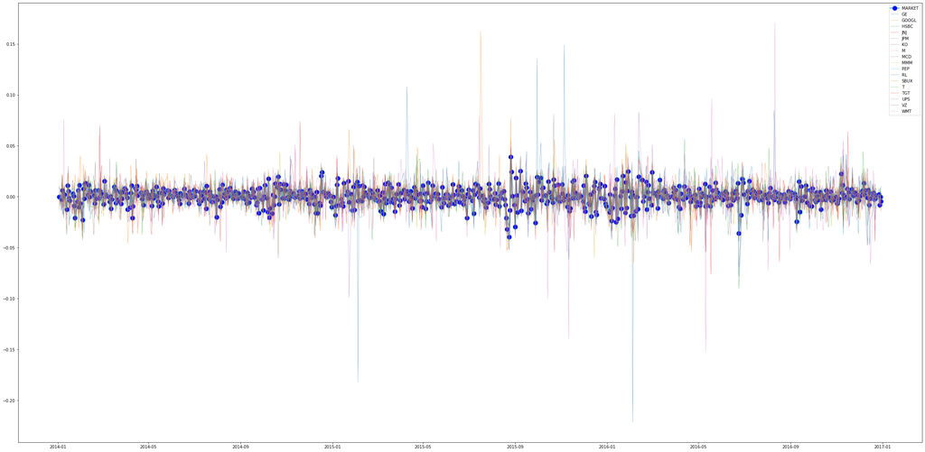

```python
plt.figure(figsize=(40,20))
plt.plot( 'Date', 'MARKET', data=Df_Return, marker='o', markerfacecolor='blue', markersize=12, color='skyblue', linewidth=4)
for i in ColHead[2:]:
    plt.plot( 'Date', i, data=Df_Return, marker='',linewidth=0.4)
plt.legend()
```

#### 2. Fit a Ordinary Least Square model for each of the stocks on the market daily return rate

#### The coefficient "k" means:

#### On every unit increase(decrease) in the market daily return rate, this spacific stock's daily return rate will increase (decrease) by k units. The stocks with larger coefficient "k" are more responses more substantially than those stocks with smaller "k". Therefore, they are more risky than those stocks with smaller "k".

#### The coefficients for each stock was stored in the dictionary named "ParamList" with the stock name as their keys.

```python
for i in ColHead[2:]:
    x = Df_Return["MARKET"]
    y = Df_Return[i]
    model = sm.OLS(y, x).fit()
    ParamList[i]=model.params

print(ParamList)
```

```
{'GE': MARKET    0.99669
dtype: float64, 'GOOGL': MARKET    1.086234
dtype: float64, 'HSBC': MARKET    0.994939
dtype: float64, 'JNJ': MARKET    0.75318
dtype: float64, 'JPM': MARKET    1.273573
dtype: float64, 'KO': MARKET    0.574549
dtype: float64, 'M': MARKET    0.843104
dtype: float64, 'MCD': MARKET    0.677315
dtype: float64, 'MMM': MARKET    0.895529
dtype: float64, 'PEP': MARKET    0.644195
dtype: float64, 'RL': MARKET    0.997969
dtype: float64, 'SBUX': MARKET    0.958479
dtype: float64, 'T': MARKET    0.612617
dtype: float64, 'TGT': MARKET    0.715398
dtype: float64, 'UPS': MARKET    0.810749
dtype: float64, 'VZ': MARKET    0.654097
dtype: float64, 'WMT': MARKET    0.606894
dtype: float64}
```

#### 3. Visualize and compare JPMorgan and Walmart

#### The Scatter plots and regression lines are generated for comparison between JPMorgan and Walmart

#### Intuitively the result is reasonable since JPMorgan belongs to the banking industry that is more sensitive to market changes while Walmart is more stable as a retailer.

#### Investors may construct their portfolio according to their risk preference base on these information.

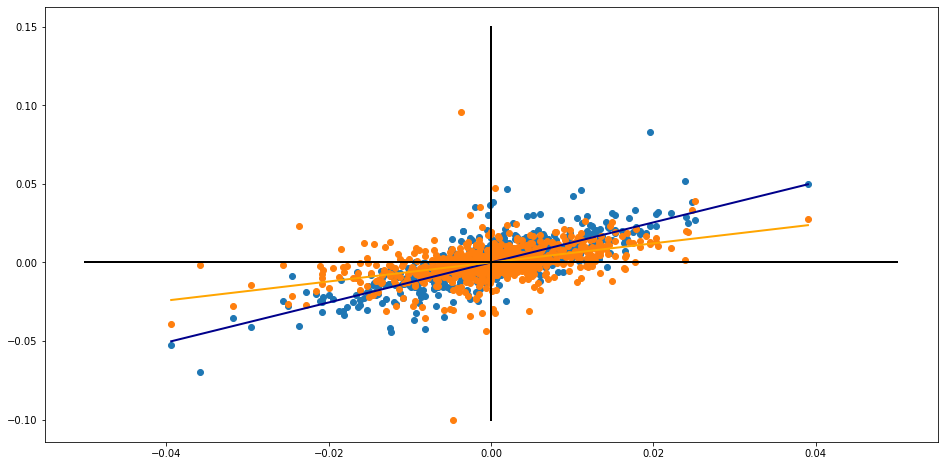

```python
x = Df_Return["MARKET"]
y = Df_Return["JPM"]
z = Df_Return["WMT"]
plt.figure(1, figsize=(16, 8))


#to plot regression line for JPM

model = sm.OLS(y, x)
fitted = model.fit()
x_pred = np.linspace(x.min(), x.max(), 50)
y_pred = fitted.predict(x_pred)
plt.plot(x_pred, y_pred, '-', color='darkblue', linewidth=2)

#to plot regression line for JPM

model = sm.OLS(z, x)
fitted2 = model.fit()
x_pred = np.linspace(x.min(), x.max(), 50)
z_pred = fitted2.predict(x_pred)
plt.plot(x_pred, z_pred, '-', color='orange', linewidth=2)

x = Df_Return["MARKET"]
y = Df_Return["JPM"]
z = Df_Return["WMT"]
plt.scatter(x,y)
plt.scatter(x,z)



plt.plot([0, 0], [-0.1, 0.15], 'k-', lw=2)
plt.plot([-0.05, 0.05], [0, 0], 'k-', lw=2)
plt.show()
```